# Diseños metodológicos y su aplicación en el campo

Santiago Benitez-Vieyra

# Estructuras de correlación

### Autocorrelación temporal

> Observaciones tomadas a lo largo de un período de tiempo pueden no ser independientes.
- Las correlaciones temporales tienen una dimensión y una sola dirección (efectos del pasado en el presente).
- Se espera que a medida de que pasa el tiempo los efectos de la autocorrelación se vuelvan menores.
- Las herramientas para detectar autocorrelación temporal son variadas.

### ¿Qué sucede si ignoramos la presencia de autocorrelación en los datos?

- El tamaño muestral se encuentra artificialmente inflado.
- Los errores estadar resultan más pequeños de lo que debieran ser, aumentando la probabilidad de cometer error de tipo I.

### Generalized Least Squares.

> Los modelos de mínimos cuadrados generalizados (Generalized least squares, GLS) son generalizaciones los mínimos cuadrados ordinarios que tienen en cuanta explícitamente la correlación entre los datos. En general son más apropiados cuando la variable respuesta es normal.

### Detectar autocorrelación temporal: lags.

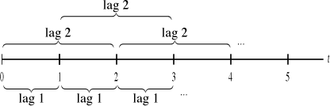

### Función de autocorrelación (ACF)

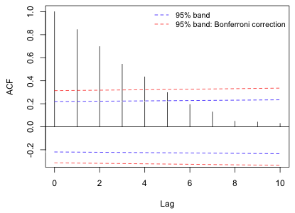

### La estructura de correlación de simetría compuesta

$$cor(\epsilon) = \begin{bmatrix}
1 & \rho & \rho & ... & \rho \\
\rho & 1 & \rho & ... & \rho \\
\rho & \rho & 1 & ... & \rho \\
... & ... & ... & 1 & \rho \\
\rho & \rho & ... & \rho & 1
\end{bmatrix}$$

### La estructura de correlación de simetría compuesta

> Asume que, independientemente de la distancia (lag) entre dos residuos, la correlación es la misma.

> Es a menudo demasiado sencilla para series de tiempo, pero puede ser útil, especialmente si la serie es corta.

### La estructura de correlación AR-1

$$cor(\epsilon) = \begin{bmatrix}
1 & \rho & \rho^2 & ... & \rho^n \\
\rho & 1 & \rho & ... & ... \\
\rho^2 & \rho & 1 & ... & ... \\
... & ... & ... & 1 & \rho \\
\rho^n & ... & ... & \rho & 1
\end{bmatrix}$$

### La estructura de correlación AR-1

> Asume que la correlación decae con el tiempo.

> A pesar de ser sencilla suele ser muy realista.

# Estructuras de correlación

### Autocorrelación espacial

> Observaciones tomadas en diferentes áreas geográficas pueden no ser independientes.
- Las correlaciones espaciales tienen al menos dose dimensiones y más de una dirección.
- Las direcciones pueden ser relevantes para la autocorrelación (**anisotropia**) o por el contrario ser irrelevantes (**isotropia**).
- Se espera que a mayor distancia los efectos de la autocorrelación se vuelvan menores.
- Las herramientas para detectar autocorrelación espacial son variadas.

### Detectar autocorrelación espacial: Bubble plots.

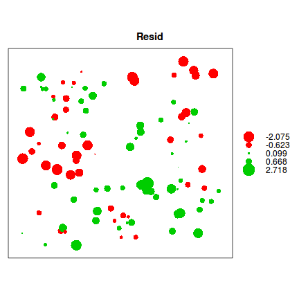

Detectar autocorrelación espacial: Variograma.

- La **semivarianza** es una medida del grado de diferencia entre dos puntos.
- Si los datos se encuentran espacialmente autocorrelacionados, aquellos más cercanos en el espacio deberían presentar respuestas semejantes, residuos semejantes y por lo tanto bajos valores de semivarianza.
- Los variogramas asumen **isotropía**, es decir la que dirección no es tenida en cuenta.

Detectar autocorrelación espacial: Variograma.

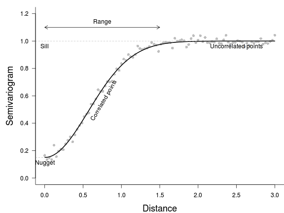

- **sill** punto hasta el cual se incrementa la semivarianza.
- **range** rango de distancias a las cuales las observaciones se encuentran autocorrelacionadas.
- **nugget** Valor de la semivarianza cuando la distancia entre los puntos es igual a cero. Típicamente resulta de variabilidad inesperada, no relacionada a la estructura espacial.

### Estructuras de correlación espacial.

| Nombre | Notación |
| --- | --- |
| **Exponencial** | ‘corExp(form=~lat+long)’ |
| **Gaussiana** | ‘corGaus(form=~lat+long)’ |
| **Lineal** | ‘corLin(form=~lat+long)’ |
| **Racional cuadrática** | ‘corRatio(form=~lat+long)’ |
| **Esférica** | ‘corSpher(form=~lat+long)’ |

### Estructuras de correlación espacial.

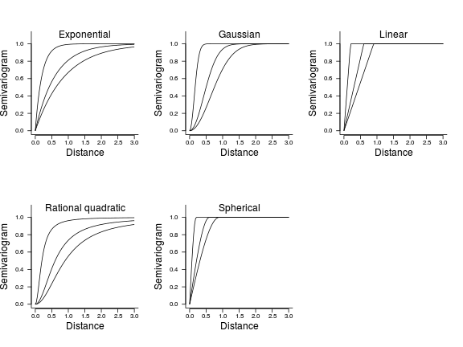